# Assignment 1

# Plots

## Plot 1

We create a correlation heatmap to visualize relationships among all numeric variables. The heatmap uses a color gradient to show the strength of the correlations. It helps us identify which audio features are strongly correlated with popularity and also whether multicollinearity may impact final model predictions.

[figure not shown]

```r
numeric_columns <- data %>%
  dplyr::select(where(is.numeric)) %>%
  dplyr::select(-any_of("ID"))

# Plot de heatmap
ggcorr(
  numeric_columns,
  label = FALSE,
  layout.exp = 1,
  low = "#7F7FFF",          # blauw voor lage correlatie
  mid = "white",
  high = "#FF4C4C",         # rood voor hoge correlatie
  name = "Correlatie"
) +
  labs(
    title = "Correlatie tussen numerieke variabelen",
    caption = "Rood = sterke correlatie, Blauw = zwak of geen correlatie"
  )
```

## Plot 2

We calculate the average values of danceability, energy, loudness, and popularity by year. A line plot is used to visualize the trends and it allows us to explore how these features evolved over time.

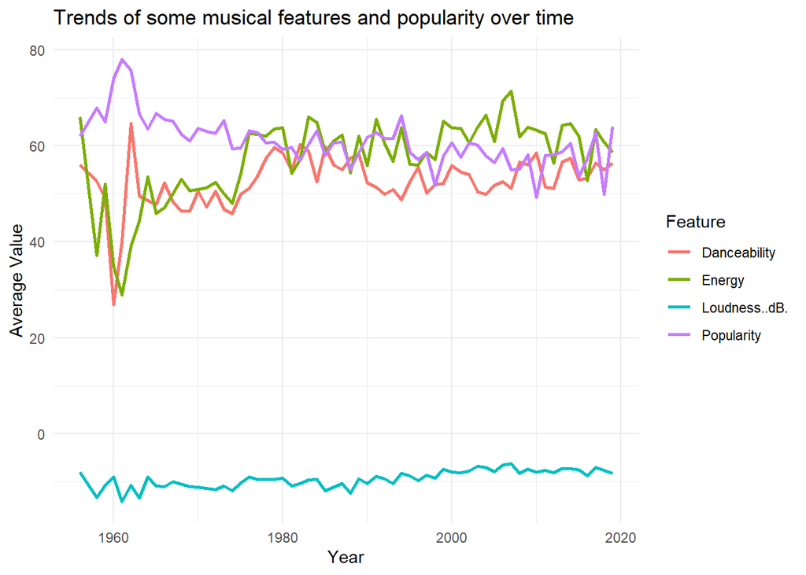

```r
data_long <- data %>%
  dplyr::select(Year, Danceability, Energy, Loudness..dB., Popularity) %>%
  pivot_longer(cols = c(Danceability, Energy, Loudness..dB., Popularity),
               names_to = "Feature",
               values_to = "Value") %>%
  group_by(Year, Feature) %>%
  summarise(Avg_Value = mean(Value, na.rm = TRUE), .groups = "drop")

ggplot(data_long, aes(x = Year, y = Avg_Value, color = Feature)) +
  geom_line(size = 1) +
  labs(title = "Trends of some musical features and popularity over time",
       x = "Year",
       y = "Average Value") +
  theme_minimal()
```